# 第2章 無作為化実験

[R2.5] クラスター化無作為化実験

作成者：川口康平

最終更新: 2024-09-16

ここでは、第2章の2.6.2項「クラスター化無作為化実験」の手法を実装する。 `CausalInferenceTextbook`から呼び出している関数は`R/functions_randomized.R`に定義されている。まず標本の潜在結果を生成し、次に、処置ベクトルと顕在結果を生成する。クラスターを一つの個体とみなしてその平均処置効果を求める場合 ($\hat{\tau}_c$) と、標本全体の平均処置効果を求める場合 ($\hat{\tau}$)の二通りの方法について考える。最後に、クラスター化無作為化実験のデータを用いて平均処置効果を推定する際のクラスター頑健推定誤差を計算する。

# 1 シミュレーションデータの生成

## 1.1 定数とパラメータの設定

```r
set.seed(1)
G <- 100
N_g <-
  rpois(
    G,
    99
  ) +
  1
N <- sum(N_g)
G_1 <- 50
```

つぎに、母集団における各クラスターの平均処置効果`tau_g_population`を標準正規分布の絶対値として抽出する。

```r
tau_g_population <-
  abs(
    rnorm(G)
  )
tau_g_population
```

```
##   [1] 0.118792026 0.197684262 1.068692711 0.803213217 1.113765136 1.580091684
##   [7] 1.497818761 0.262645459 1.232901200 0.003723534 1.511672283 0.475698284
##  [13] 0.797916438 0.974002561 0.689372698 0.955839103 1.231707058 0.956891881
##  [19] 0.869782874 0.910680682 0.741276305 0.068511533 0.323750755 1.086503047
##  [25] 1.015928947 0.767790185 1.119720061 0.448174237 0.471736374 1.180490683
##  [31] 1.470256997 1.311420592 0.096524923 2.369719908 0.890626476 0.252183161
##  [37] 0.865763755 0.582586000 0.012529347 0.374854762 0.317885735 0.488805635
##  [43] 2.658658027 1.680278205 0.779584009 0.713240520 0.542881937 0.885778374
##  [49] 0.348594685 1.008054578 1.883182542 0.928971079 0.294196454 0.614950271
##  [55] 0.947075792 0.598975150 1.523614882 0.206189002 0.574295414 1.390166037
##  [61] 0.070417383 0.430879530 0.592225373 0.981116160 0.532409357 0.090456124
##  [67] 0.156490492 0.737311691 0.201341206 1.102176595 0.016748256 0.161788634
##  [73] 2.024761390 0.703694254 0.960792384 1.790485054 1.064165163 0.017636546
##  [79] 0.389908629 0.490832752 1.045717652 0.896211264 1.269387164 0.593840949
##  [85] 0.775634319 1.557370376 0.365401797 0.816556449 0.060634778 0.501378318
##  [91] 0.926062725 0.036937691 1.066200174 0.238456353 1.495223444 1.172158547
##  [97] 1.457707210 0.095056227 0.847664964 1.624364530
```

母集団における平均処置効果`tau_population`は、この`tau_g_population`をクラスターの標本数で重み付けした平均として定義される。

```r
tau_population <-
  sum(
    tau_g_population * N_g /
    N
  )
tau_population
```

```
## [1] 0.7998756
```

各クラスターを一個体ととみなしたときの母集団における単純平均効果`tau_c_population`は`tau_g_population`の単純平均として定義される。

```r
tau_c_population <- mean(tau_g_population)
tau_c_population
```

```
## [1] 0.8044622
```

## 1.2 データの生成

以上の定数とパラメーターを元に標本の潜在結果を生成する。この操作が一回の無作為抽出にあたる。

```r
outcome_potential <-
  1:G %>%
  purrr::map(
    .,
    ~ tibble::tibble(
      g = .,
      y_0 =
        rnorm(
          N_g[.],
          mean = 0,
          sd = 1
        ),
      y_1 =
        rnorm(
          N_g[.],
          mean = tau_g_population[.],
          sd = 1
        )
    )
  ) %>%
  dplyr::bind_rows()

outcome_potential %>%
  head() %>%
  kbl() %>%
  kable_styling()
```

| g | y_0 | y_1 |
| --- | --- | --- |
| 1 | 1.4085634 | 0.4271008 |
| 1 | -0.5417604 | 0.4635871 |
| 1 | 0.2786647 | 1.6584401 |
| 1 | -0.1939727 | -0.2107222 |
| 1 | 1.5761582 | 1.0671814 |
| 1 | -1.4755476 | -0.3604636 |

```r
outcome_potential %>%
  modelsummary::datasummary_skim()
```

Unique

Missing Pct.

Mean

SD

Min

Median

Max

Histogram

g

100

0

50.7

28.8

1.0

51.0

100.0

[figure not shown]

y_0

10116

0

0.0

1.0

-3.5

0.0

3.5

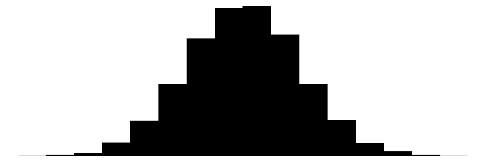

y_1

10116

0

0.8

1.1

-3.0

0.8

5.3

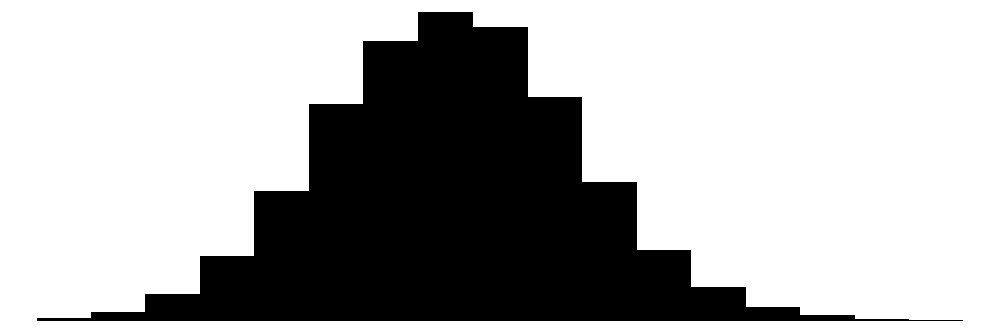

無作為抽出された標本における各クラスターの平均処置効果`tau_g`も計算する。

```r
tau_g <-
  outcome_potential %>%
  dplyr::group_by(g) %>%
  dplyr::summarise(
    tau =
      mean(
        y_1 - y_0
      )
  ) %>%
  dplyr::pull(tau)

tau_g
```

```
##   [1]  0.101574668  0.002039474  1.213023727  0.773117738  1.369691583
##   [6]  1.590797473  1.607915561  0.263939932  1.223844275  0.053168542
##  [11]  1.587090166  0.571237782  0.918174756  0.825600635  0.754736189
##  [16]  1.088649299  1.126458196  0.860518498  0.866642407  1.042723198
##  [21]  0.241890716  0.066733255  0.267929611  1.212721344  1.128297907
##  [26]  0.820550719  1.067973420  0.193279754  0.269017280  1.171357382
##  [31]  1.244023226  1.241180513 -0.091438672  2.507565671  0.706139123
##  [36]  0.240291588  1.009180140  0.563651197 -0.178108353  0.560035914
##  [41]  0.343315110  0.480742843  2.841424990  1.557100514  0.869533845
##  [46]  0.913741777  0.613246413  0.554918872  0.078269815  1.330750908
##  [51]  1.973828144  1.015048980  0.442022632  0.425402926  0.962140533
##  [56]  0.444499818  1.501133297 -0.025104042  0.344077266  1.455974054
##  [61]  0.219671604  0.547092852  0.768251627  1.253254507  0.337174548
##  [66]  0.034241031  0.087653057  0.773899682 -0.083725398  1.118691613
##  [71]  0.095213207  0.201709381  1.870576388  0.719756370  0.914994143
##  [76]  2.049243060  0.896403506 -0.008733061  0.390127272  0.401169172
##  [81]  1.021824552  1.085941989  1.282727769  0.784296958  0.540884270
##  [86]  1.700433899  0.391150165  0.771928827 -0.099581903  0.698656975
##  [91]  0.909681493 -0.044618175  1.064411493 -0.083461677  1.600216567
##  [96]  1.111913973  1.498195240  0.133968918  0.895842033  1.368991466
```

無作為抽出された標本における平均処置効果`tau`も計算する。

```r
tau <-
  outcome_potential %>%
  dplyr::summarise(
    tau =
      mean(
        y_1 - y_0
      )
  ) %>%
  dplyr::pull(tau)

tau
```

```
## [1] 0.7909974
```

無作為抽出された標本における単純平均効果`tau_c`も計算する。

```r
tau_c <- mean(tau_g)
tau_c
```

```
## [1] 0.7942535
```

次に、観察されるデータを生成する。そのために、まず処置ベクトル`z`を生成する。この操作が一回の無作為化実験にあたる。ここではクラスター化無作為化実験を考えるので、処置の割当はクラスター内の個体で完全に一致する。実現した処置ベクトルと潜在結果から、顕在結果を計算する。この結果作成される`data_realized`が実際に観測されるデータになる。

```r
data_realized <-
  generate_data_cluster(
    outcome_potential = outcome_potential,
    G_1 = G_1,
    seed = 1
  )
data_realized %>%
  head() %>%
  kbl() %>%
  kable_styling()
```

| g | z | y |
| --- | --- | --- |
| 1 | 1 | 0.4271008 |
| 1 | 1 | 0.4635871 |
| 1 | 1 | 1.6584401 |
| 1 | 1 | -0.2107222 |
| 1 | 1 | 1.0671814 |
| 1 | 1 | -0.3604636 |

# 2 分析

## 2.1 平均の差による$\hat{\tau}_c$の推定

```r
tau_c_hat <-
  data_realized %>%
  dplyr::group_by(g) %>%
  dplyr::summarise(
    z = mean(z),
    y = mean(y)
    ) %>%
  dplyr::ungroup() %>%
  dplyr::summarise(
    tau =
      sum(y * z) /
      sum(z) -
      sum(y * (1 - z)) /
      sum(1 - z)
  )
tau_c_hat
```

| tau |
| --- |
| 0.8253962 |

## 2.2 $\hat{\tau}_c$の標準誤差

```r
tau_c_hat_se <-
  data_realized %>%
  dplyr::group_by(g) %>%
  dplyr::summarise(
    z = mean(z),
    y = mean(y)
    ) %>%
  dplyr::ungroup() %>%
  dplyr::group_by(z) %>%
  dplyr::summarise(
    G_z = length(y),
    variance =
      sum(
        (y - mean(y))^2 /
        (G_z - 1)
      )
  ) %>%
  dplyr::ungroup() %>%
  dplyr::summarise(
    se =
      sum(
        variance /
        G_z
      ) %>%
      sqrt()
  )

tau_c_hat_se
```

| se |
| --- |
| 0.0903639 |

## 2.3 回帰分析による$\hat{\tau}_c$の推定

```r
tau_c_hat_regression <-
  data_realized %>%
  dplyr::group_by(g) %>%
  dplyr::summarise(
    z = mean(z),
    y = mean(y)
    ) %>%
  dplyr::ungroup() %>%
  lm(
    data = .,
    formula = y ~ z
  )
```

## 2.4 $\hat{\tau}_c$の推定結果

```r
tau_c_hat_regression %>%
  modelsummary(
    fmt = 6
  )
```

|  | (1) |
| --- | --- |
| (Intercept) | 0.000097 |
|  | (0.063897) |
| z | 0.825396 |
|  | (0.090364) |
| Num.Obs. | 100 |
| R2 | 0.460 |
| R2 Adj. | 0.454 |
| AIC | 128.9 |
| BIC | 136.7 |
| Log.Lik. | -61.436 |
| RMSE | 0.45 |

## 2.5 平均の差による$\hat{\tau}$の推定

```r
tau_hat <-
  data_realized %>%
  dplyr::summarise(
    tau =
      sum(y * z) /
      sum(z) -
      sum(y * (1 - z)) /
      sum(1 - z)
  )
tau_hat
```

| tau |
| --- |
| 0.8233537 |

## 2.6 回帰分析による$\hat{\tau}$の推定

```r
tau_hat_regression <-
  data_realized %>%
  dplyr::mutate(
    z =
      z %>%
      as.integer()
    ) %>%
  lm(
    data = .,
    formula = y ~ z
  )
```

## 2.7 $\hat{\tau}$の推定結果

```r
tau_hat_regression %>%
  modelsummary(
    vcov = ~ g,
    fmt = 6
  )
```

|  | (1) |
| --- | --- |
| (Intercept) | 0.001135 |
|  | (0.016369) |
| z | 0.823354 |
|  | (0.091533) |
| Num.Obs. | 10116 |
| R2 | 0.126 |
| R2 Adj. | 0.126 |
| AIC | 30362.6 |
| BIC | 30384.3 |
| Log.Lik. | -15178.324 |
| RMSE | 1.08 |
| Std.Errors | by: g |

## 2.8 $\hat{\tau}$の標準誤差の手動計算

```r
se_cluster_robust <-
  data_realized %>%
  dplyr::mutate(
    constant = 1,
    epsilon = tau_hat_regression$residuals
  )

term_1 <-
  se_cluster_robust %>%
  dplyr::select(
    constant,
    z
  ) %>%
  as.matrix()
term_1 <-
  crossprod(
    term_1,
    term_1
  )
```

```r
term_2 <-
  se_cluster_robust %>%
  dplyr::group_split(g) %>%
  purrr::map(
    .,
    function(df) {
      df <-
        df %>%
        dplyr::mutate(
          z_epsilon = z * epsilon
        ) %>%
        dplyr::select(
          epsilon,
          z_epsilon
        ) %>%
        dplyr::summarise_all(sum) %>%
        as.matrix()
      df <-
        crossprod(
          df,
          df
        )
    }
  ) %>%
  purrr::reduce(`+`)
```

```r
se_cluster_robust <-
  solve(
    term_1,
    term_2
  ) %*%
  solve(term_1)
se_cluster_robust %>%
  diag() %>%
  sqrt()
```

```
##   constant          z
## 0.01628632 0.09106931
```